# R Notebook

```r
library(conjoint)
library(lme4)
library(MCMCpack)
data(chocolate)
```

**Chocolate** is a dataset from the conjoint package. The variables used will be **kind** with 4 levels (milk, walnut, delicaties, dark), **price** with 3 levels (low, average, high), **packing** with 2 levels (paperback, hardback), **weight** with 3 levels (light, middle, heavy), and **calorie** with 2 levels (little, much).

**Description of the data provided in chocolate:**

- **cpref** = Vector of preferebces (ratings) only - length 1392 (87 respondents x each respondent shown 16 profiles = 1392).
- **cprefm** = Matrix of preferences (87 respondents and 16 profiles).
- **cprof** = Matrix of profiles (5 attributes and 16 full profiles)
- **clevn** = Character vector of names for the attributes’ levels
- **csimp** = Matrix of simulation profiles.

### Question 1: Use journey or chocolate data from package conjoint. Perform the following analyses: (2 points)

#### Question 1.1: Partworth estimation for all individuals separately

```r
individual_partworths <- caPartUtilities(cprefm, cprof, clevn)
print(head(individual_partworths))
```

```
##      intercept  milk walnut delicaties  dark    low average   high paperback
## [1,]     8.583  2.00  -2.00       6.00 -6.00  0.000  -0.250  0.250     0.000
## [2,]     8.500  0.00  -2.75       0.50  2.25 -2.667   0.333  2.333     0.500
## [3,]     8.625 -6.00   2.00      -2.00  6.00 -0.667  -0.167  0.833     0.375
## [4,]     8.208 -2.00   0.25      -1.75  3.50  2.333   0.333 -2.667    -0.750
## [5,]     8.833 -1.75   0.75      -4.50  5.50 -1.333  -0.583  1.917     0.375
## [6,]     8.292 -2.25  -2.50       5.25 -0.50  0.500   0.875 -1.375    -0.375
##      hardback  light middle  heavy little   much
## [1,]    0.000 -0.333 -0.083  0.417 -1.000  1.000
## [2,]   -0.500  2.667 -1.083 -1.583  0.250 -0.250
## [3,]   -0.375  0.167  0.042 -0.208 -0.375  0.375
## [4,]    0.750 -1.167  2.458 -1.292  0.125 -0.125
## [5,]   -0.375  0.000  1.500 -1.500 -0.750  0.750
## [6,]    0.375  0.333  0.333 -0.667  0.625 -0.625
```

**individual_partworths:** 87x15 matrix where each row = respondent, and each column = estimate partworth for a specific attribute level.

#### Question 1.2: Partworth estimation by combining all individual responses into an aggregate

```r
aggregate_partworths <- caUtilities(cprefm, cprof, clevn)
```

```
##
## Call:
## lm(formula = frml)
##
## Residuals:
##      Min       1Q   Median       3Q      Max
## -11,3305  -3,5546   0,4799   3,4799   9,8190
##
## Coefficients:
##                    Estimate Std. Error t value Pr(>|t|)
## (Intercept)         8,68487    0,12648  68,667  < 2e-16 ***
## factor(x$kind)1    -1,08908    0,19815  -5,496 4,62e-08 ***
## factor(x$kind)2    -0,73276    0,19815  -3,698 0,000226 ***
## factor(x$kind)3    -0,92241    0,19815  -4,655 3,55e-06 ***
## factor(x$price)1   -0,57088    0,15254  -3,743 0,000190 ***
## factor(x$price)2    0,11877    0,17887   0,664 0,506777
## factor(x$packing)1 -0,02874    0,11440  -0,251 0,801714
## factor(x$weight)1  -0,16858    0,15254  -1,105 0,269272
## factor(x$weight)2   0,17337    0,17887   0,969 0,332575
## factor(x$calorie)1 -0,64655    0,11440  -5,652 1,93e-08 ***
## ---
## Signif. codes:  0 '***' 0,001 '**' 0,01 '*' 0,05 '.' 0,1 ' ' 1
##
## Residual standard error: 4,268 on 1382 degrees of freedom
## Multiple R-squared:  0,1488, Adjusted R-squared:  0,1433
## F-statistic: 26,85 on 9 and 1382 DF,  p-value: < 2,2e-16
```

```r
print(aggregate_partworths)
```

```
##  [1]  8.684865900 -1.089080460 -0.732758621 -0.922413793  2.744252874
##  [6] -0.570881226  0.118773946  0.452107280 -0.028735632  0.028735632
## [11] -0.168582375  0.173371648 -0.004789272 -0.646551724  0.646551724
```

#### Question 1.3: Partworth estimation by using linear mixed models.

In this case, you should treat each individual as a separate group for defining the random effects

```r
df <- data.frame(
  respondent = rep(1:nrow(cprefm), each = ncol(cprefm)),
  profile = rep(1:ncol(cprefm), times = nrow(cprefm)),
  ranking = as.vector(as.matrix(cprefm))
)


profiles <- data.frame(profile = 1:nrow(cprof), cprof)
df <- merge(df, profiles, by = "profile")
df$kind <- as.factor(df$kind)
df$price <- as.factor(df$price)
df$packing <- as.factor(df$packing)
df$weight <- as.factor(df$weight)
df$calorie<-as.factor(df$calorie)
```

```r
lmm_model <- lmer(
  ranking ~ kind + price + packing + weight + calorie + (1 | respondent),  # Random effect for respondents
  data = df
)
```

```r
summary(lmm_model)
```

```
## Linear mixed model fit by REML ['lmerMod']
## Formula: ranking ~ kind + price + packing + weight + calorie + (1 | respondent)
##    Data: df
##
## REML criterion at convergence: 8109.2
##
## Scaled residuals:
##      Min       1Q   Median       3Q      Max
## -2.61118 -0.81595  0.04466  0.79747  2.42514
##
## Random effects:
##  Groups     Name        Variance Std.Dev.
##  respondent (Intercept)  3.189   1.786
##  Residual               18.139   4.259
## Number of obs: 1392, groups:  respondent, 87
##
## Fixed effects:
##              Estimate Std. Error t value
## (Intercept)  8.537835   0.229307  37.233
## kind1       -0.178161   0.197717  -0.901
## kind2        0.183908   0.197717   0.930
## kind3       -0.252874   0.197717  -1.279
## price1      -0.157088   0.152203  -1.032
## price2       0.176245   0.178474   0.988
## packing1    -0.015805   0.114152  -0.138
## weight1      0.005747   0.152203   0.038
## weight2     -0.214080   0.178474  -1.200
## calorie1    -0.018678   0.114152  -0.164
##
## Correlation of Fixed Effects:
##          (Intr) kind1  kind2  kind3  price1 price2 pckng1 weght1 weght2
## kind1     0.000
## kind2     0.000 -0.333
## kind3     0.000 -0.333 -0.333
## price1   -0.166  0.000  0.000  0.000
## price2    0.071  0.000  0.000  0.000 -0.426
## packing1  0.000  0.000  0.000  0.000  0.000  0.000
## weight1  -0.166  0.000  0.000  0.000  0.000  0.000  0.000
## weight2   0.071  0.000  0.000  0.000  0.000  0.000  0.000 -0.426
## calorie1  0.000  0.000  0.000  0.000  0.000  0.000  0.000  0.000  0.000
```

### Question 3: Perform cluster analysis of each individual’s partworths to define Benefit segments.

For this purpose, use the partworths from steps 1,3, or 4 that has the best predictions for the holdout data from step 2. (2 points)

```r
wss = numeric(10)
for (k in 1:10){
  mod = kmeans(individual_partworths, centers = k,
               nstart = 1000)
  wss[k] = mod$tot.withinss
}
```

```r
# within cluster sum of squares
wss
```

```
##  [1] 4903.721 3612.618 2946.498 2497.467 2134.366 1913.644 1740.117 1586.442
##  [9] 1448.490 1340.094
```

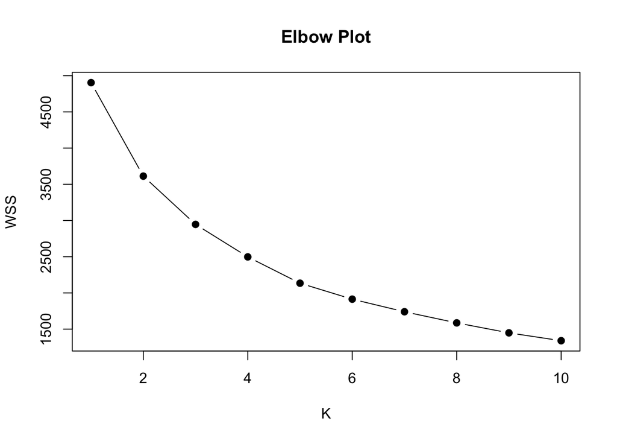

```r
# elbow plot
plot(1:10, wss,type = "b", pch = 19, xlab = "K", ylab = "WSS",
     main = "Elbow Plot")
```

Optimal K seems to be k = 4 based on the curve of the plot.

```r
mod = kmeans(individual_partworths, centers = 4,
               nstart = 1000)
```

```r
# cluster centers
mod$centers
```

```
##   intercept      milk     walnut delicaties       dark        low     average
## 1  8.487500  2.600000  3.3750000 -2.6750000 -3.3000000 -0.2168000 -0.12930000
## 2  8.869318 -1.204545 -1.0681818  2.9545455 -0.6818182 -1.2955909  0.28963636
## 3  8.567708  1.229167 -2.0208333 -4.3020833  5.0937500 -0.1597500  0.26212500
## 4  8.708323 -3.991935 -0.8225806 -0.4919355  5.3064516 -0.4893226 -0.03367742
##         high  paperback   hardback      light     middle       heavy     little
## 1  0.3457000  0.1750000 -0.1750000  0.2668000 -0.0832000 -0.18320000 -0.7375000
## 2  1.0055455  0.1079545 -0.1079545 -0.1818182 -0.2613636  0.44318182 -0.7329545
## 3 -0.1024583 -0.1250000  0.1250000 -0.1111250  0.3888750 -0.27779167 -0.2239583
## 4  0.5227742 -0.1169355  0.1169355 -0.3441290  0.3978065 -0.05380645 -0.8830645
##        much
## 1 0.7375000
## 2 0.7329545
## 3 0.2239583
## 4 0.8830645
```

Each row is a cluster’s average partworths.

```r
# cluster assignments
mod$cluster
```

```
##  [1] 2 2 4 4 3 2 4 1 3 3 3 2 4 2 2 3 2 3 2 2 4 3 3 3 4 1 3 2 4 3 1 2 2 4 2 1 3 4
## [39] 1 4 3 4 3 4 4 4 4 4 3 3 4 2 2 1 2 4 2 4 2 4 4 4 4 3 4 2 4 1 2 3 4 3 4 3 3 4
## [77] 4 4 3 1 2 2 1 3 4 3 1
```

Assigning each respondent to one of the 4 clusters.

### Question 4: Build a simulator that takes as input 4 or 5 input concepts, and produces market share estimates.

```r
marketshares = caLogit(csimp, cprefm, cprof)
marketshares
```

```
## [1] 49.81532 25.20706 12.65507 12.32256
```

Estimation of the % of preference (market shares) for each of the 4 proposed product concepts (rows of csimp), averaged across all respondents.